# Community Futures

## Tricys Consulting

### Outsourcing data analytics and research has never been easier

Community Futures Presentation  
Yuri Tricys  
Data Analyst

## A little bit about me:

- I am a researcher specializing in data analytics and R programming
- I also code in: GAMS, HTML5, CSS, JavaScript, jQuery, PHP and, MySQL
- I've always had a passion to learn and discover new skills
- I assembled my first computer from stock parts in 2000
- In 2009, I began writing scripts in Stata, at UBC (Stata is data analysis software)
- In 2012, almost a year after graduation from UBC, a former professor e-mailed me and asked me to do research assistance. It must have been those essays I wrote (needless to say at that time they were my best work)

## A little bit about me:

- I would spend the next 3 years working on a number of code intensive projects
- I learned a lot about data in those three years!

[figure not shown]

## Data now and tomorrow:

- It was during that 3 year period, putting the big hours into data coding, that I began looking at the fast changing global technological landscape

### OUR WORLD WAS CHANGING AND IT WAS CHANGING FAST!

## Data now and tomorrow:

### IT'S STILL CHANGING

- You can't see it, but demand for data analytics is growing at a lightning pace, and it's only getting started

[figure not shown]

## Demand for data analytics:

- According to McKinsey Global Institute, by 2018, the U.S. alone will face a shortage of about 190,000 data scientists, and 1.5 million analysts and managers that 'get' big data
- The ICTC (Information and Communications Technology Council) reports Canada will need 182,000 people to fill IT positions by 2019. Those positions with the highest demand (nonordinal):
  - Information systems analysts and consultants
  - Computer and network operators and web technicians
  - **Computer programmers and interactive media developers**
  - Software engineers
  - Graphic designers and illustrators
  - Computer and information systems managers
  - **Database analysts and data administrators**

## Tricys Consulting:

- Profile: *A small data shop situated at the intersection of data science and research. Tricys Consulting will gather, wrangle, maintain, and analyse data,and prepare publishable results*
- Mission: *To equip organizations with data rich analytics so they can better achieve their directives*

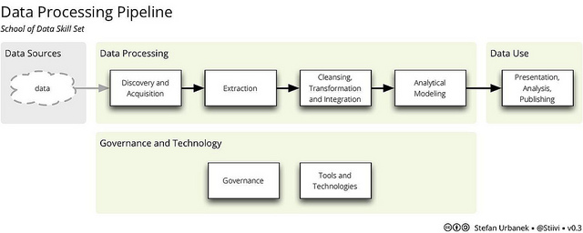

## Tricys Consulting:

### SERVICES:

1. Auxiliary Research Services: diagrams, tables, flow-charts, summaries, graphs, interactive web charts, slides, brief reports
2. Research Services: evaluating research demand, research feasibility, data science, research, graphical representation, editing, generating and refining research questions, project planning, model selection, simulation, sensitivity analysis, academic writing, publication preparation

## Tricys Consulting:

### LOCAL DEMAND:

- There are local companies and organizations that work with data including:
  - Core Logic
  - Selkirk College
  - Thought Exchange
  - I4C iNNOVATiON
- I4C iNNOVATiON is currently outsourcing data services
- Thought Exchange has in house data analysts

## Tricys Consulting

### NONLOCAL DEMAND:

- There are a lot more nonlocal companies working with data
  - Clean Energy Canada outsources all of the services we are offering
  - Visual Capitalist is currently doing in house data collection but potentially looking outside for that service

### LOCAL COMPETITION

- There are no remote data analysts in Nelson offering data analytics services

## Summary:

- In the midst of the communications revolution the data landscape is growing fast
- Data analytics are right now in big demand, and will be even more so in coming years
- Tricys Consulting has the skills and experience to perform in demand data analytics services
- There is so far evidence of both local and external demand for remote data analytics services
- Going into the data analytics business as a self-employed data analyst makes sense, right now

## Last slide:

[figure not shown]